# Investigating Global Trends in Measles and Rubella Cases

Author

Hailey Ernest and Nicole Yee

[figure not shown]

Measles and rubella are highly contagious diseases for which vaccines are widely available. Although rubella outbreaks are relatively uncommon, measles outbreaks continue to occur fairly often and remain a risk in terms of public health. In this report, we investigate patterns in measles and rubella cases to provide insight into how these diseases vary across the world and over time.

## Data Context

```r
# function to scrape one year of gdp data
scrape_gdp_year <- function(year) {

  # create url for a specific year
  url <- glue("https://ourworldindata.org/grapher/gdp-per-capita-worldbank?tab=table&time={year}..{year}&tableFilter=countries")

  # open browser session: page is dynamic (live)
  b <- ChromoteSession$new()

  # browser closes after function
  on.exit(try(b$close(), silent = TRUE), add = TRUE)

  # go to page
  b$Page$navigate(url)

  # wait for loaded table
  Sys.sleep(5)

  # get rendered html from the page
  eval_result <- b$Runtime$evaluate("document.documentElement.outerHTML")
  rendered_html <- eval_result$result$value

  # read html into r
  page <- read_html(rendered_html)

  # extract the table from the page
  tab <- page |>
    html_element("table") |>
    html_table()

  # keep only country and gdp
  tab_clean <- tab[, 1:2]
  names(tab_clean) <- c("country", "gdp_per_capita")

  # clean the data
  tab_clean <- tab_clean |>
    mutate(
      scraped_year = year, # year
      gdp_per_capita = str_remove_all(gdp_per_capita, "\\$|,"), # remove $ and ,
      gdp_per_capita = na_if(gdp_per_capita, ""), # empty is NA
      gdp_per_capita = as.numeric(gdp_per_capita) # convert to numeric
    ) |>
    filter(country != "Country or region") |>
    filter(!is.na(country))
  tab_clean
}

# create vector of years to scrape
years <- 2012:2024

# loop over all years, then combine
gdp_web <- map_dfr(years, scrape_gdp_year)
```

```r
# Ensure countries are joined cleanly
clean_country <- function(x) {
  x |>
    stri_trans_general("Latin-ASCII") |>
    str_to_lower() |>
    str_replace_all("&", "and") |>
    str_remove_all("[[:punct:]]") |>
    str_squish()
}

# Change country names that don't align with the measles data
gdp_web_clean <- gdp_web |>
  rename(year = scraped_year) |>
  mutate(
    year = as.numeric(year),
    country_join = recode(country,
      "United States" = "United States of America",
      "Bolivia" = "Bolivia (Plurinational State of)",
      "Venezuela" = "Venezuela (Bolivarian Republic of)"
    ),
    country_key = clean_country(country_join)
  )

# Clean countries and years
cases_year_clean <- cases_year |>
  mutate(
    year = as.numeric(year),
    country_key = clean_country(country)
  )

# join the yearly gdp with yearly cases data
cases_year_gdp <- cases_year_clean |>
  left_join(
    gdp_web_clean |>
      select(country_key, year, gdp_per_capita),
    by = c("country_key", "year")
  )

# join the yearly gdp/cases data to the monthly cases data
cases_gdp <- cases_month |>
  left_join(
    cases_year_gdp,
    by = c("country", "year"),
    suffix = c("_month", "_year")
  ) |>
  # make a tibble to join
  as_tibble()

# create yearly country-level dataset with GDP joined, and clean readable names
cases_gdp_year <- cases_year |>
  filter(year != 2025) |>
  mutate(
    year = as.numeric(year),
    measles_epi_linked = as.numeric(measles_epi_linked)
  ) |>
  left_join(
    gdp_web |>
      rename(year = scraped_year) |>
      select(country, year, gdp_per_capita),
    by = c("country", "year")
  ) |>
  mutate(
    region = recode(region,
      "AFRO" = "Africa",
      "AMRO" = "Americas",
      "EMRO" = "Eastern Mediterranean",
      "EURO" = "Europe",
      "SEARO" = "South-East Asia",
      "WPRO" = "Western Pacific"
    )
  ) |>
  filter(
    !is.na(measles_epi_linked),
    !is.na(gdp_per_capita),
    measles_epi_linked > 0
  )
```

In this report, we utilized data from several sources. Our main focus is centered around measles and rubella cases, but we incorporated additional data about GDP.

Our main set of data presents suspected and confirmed classification of measles and rubella cases across regions and countries in the world. It is presented in two forms: monthly case counts and yearly summaries. The data is collected and reported by healthcare providers and national surveillance systems and compiled by the World Health Organization (WHO). The data was downloaded on June 12, 2025, and is finalized by July of each year. The data covers regions and countries worldwide. The data is collected to track and confirm measles and rubella cases across populations over time. Suspected measles cases are identified based on symptoms or clinical judgment, reported through national surveillance systems to the WHO, and then classified as clinically compatible, epidemiologically linked, or laboratory-confirmed, with total measles cases calculated as the sum of these categories for most countries.

We additionally used country-level GDP per capita data, where the observations are countries and regions around the world. The data includes over 200 countries’ GDP, and ranges from 1990 to 2024. GDP per capita is calculated by dividing a country’s total output by its population and adjusting values with the same international dollars to take into account inflation and living cost differences. The goal of this data is to compare economic performance, living conditions, and economic growth across almost all countries over many years. The data is created by organizations such as the World Bank, IMF, OECD, and Eurostat, and is summarized by Our World in Data. GDP data is collected by national statistical agencies using censuses, surveys, and tax or government data, and then analyzed and organized by the World Bank, IMF, etc.

## Our areas of interest

In this report, we analyzed the data to gain insight into two areas of interest listed below.

1. Globally, has there been improvement in containing measles and rubella cases in recent years and is there a time of year where these cases become more common?
2. Are countries with lower GDP per capita associated with higher numbers of epidemiologically linked measles cases and does this relationship vary by region?

### Investigating measles and rubella in relation to time

We begin by looking into if there is notable improvement in global disease containment in recent years, and if there is a time of year where cases are more common.

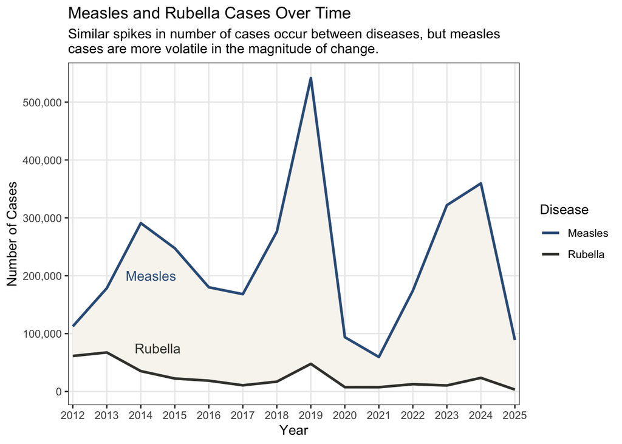

Figure 1. Trends in Measles and Rubella Cases

```r
annotate_text <- tibble(
  year = c(2014.5, 2014.3),
  y_lab = c(75000, 200000),
  disease = c("Rubella", "Measles")
)

cases_year |>
  group_by(year) |>
  summarize(measles = sum(measles_total, na.rm = TRUE),
            rubella = sum(rubella_total, na.rm = TRUE)) |>
  ggplot() +
  geom_ribbon(aes(x = year, ymin = measles, ymax = rubella),
              position = "identity",
              inherit.aes = FALSE,
              fill = "#F8F5F0") +
  geom_line(aes(x = year,
                y = measles,
                color = "Measles"),
            linewidth = 1) +
  geom_line(aes(x = year,
                y = rubella,
            color = "Rubella"),
            linewidth = 1) +
  scale_color_manual(name = "Disease",
                     values = c("Measles" = "#325D88", "Rubella" = "#3E3F3A")) +
  scale_x_continuous(breaks = unique(cases_year$year),
                     expand = c(0.01,0.01)) +
  scale_y_continuous(breaks = seq(0, 600000, by = 100000),
                     labels = scales::label_comma()) +
  geom_text(data = annotate_text,
            mapping = aes(x = year,
                          y = y_lab,
                          label = disease,
                          color = disease),
            inherit.aes = FALSE,
            show.legend = FALSE
            ) +
  theme_bw() +
  labs(x = "Year",
       y = "Number of Cases",
       title = "Measles and Rubella Cases Over Time",
       subtitle = "Similar spikes in number of cases occur between diseases, but measles \ncases are more volatile in the magnitude of change.") +
  theme(panel.grid.minor = element_blank())
```

```r
cases_year |>
  group_by(year) |>
  summarize(
    total_measles = sum(measles_total, na.rm = TRUE),
    total_rubella = sum(rubella_total, na.rm = TRUE),
    .groups = "drop") |>
  mutate(
    median_measles = median(total_measles),
    median_rubella = median(total_rubella),
    measles_vs_median = total_measles - median_measles,
    rubella_vs_median = total_rubella - median_rubella,
    measles_pct = (total_measles - median_measles) / median_measles,
    rubella_pct = (total_rubella - median_rubella) / median_rubella) |>
  select(year, measles_pct, rubella_pct) |>
  gt()  |>
  cols_label(
     year = md("**Year**"),
     measles_pct = md("**Measles**"),
     rubella_pct = md("**Rubella**")
   ) |>
   # add a table title
   tab_header(title = md("Difference in Measles and Rubella Cases Each Year Compared to the Typical Number of Cases")) |>
   # add a table caption
   tab_caption(caption = md("Percent change in cases compared to the overall median number of measles and rubella cases.")) |>
   # bold column labels
   tab_style(
     style = cell_text(weight = "bold"),
     locations = cells_column_labels()
   ) |>
  fmt_percent(columns = c(measles_pct, rubella_pct), decimals = 2)
```

Table 1. Case Counts Compared to the Median Case Count

Difference in Measles and Rubella Cases Each Year Compared to the Typical Number of Cases

| **Year** | **Measles** | **Rubella** |
| --- | --- | --- |
| 2012 | −37.22% | 243.65% |
| 2013 | −0.42% | 277.52% |
| 2014 | 62.26% | 97.11% |
| 2015 | 38.05% | 25.51% |
| 2016 | 0.42% | 4.57% |
| 2017 | −6.18% | −40.03% |
| 2018 | 54.04% | −4.57% |
| 2019 | 202.00% | 167.42% |
| 2020 | −47.65% | −58.01% |
| 2021 | −66.74% | −58.52% |
| 2022 | −2.75% | −29.35% |
| 2023 | 79.55% | −41.66% |
| 2024 | 100.55% | 31.97% |
| 2025 | −50.44% | −81.60% |

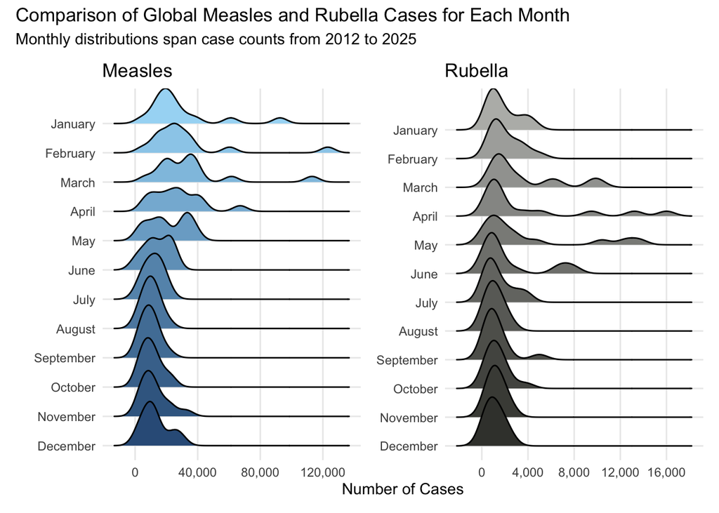

Figure 2. Measles and Rubella Cases by Month

```r
color_gradient <- colorRampPalette(c("#A6DAF5", "#325D88"))(12)
names(color_gradient) <- month.name

measles <- cases_month |>
  group_by(month, year) |>
  summarise(measles_total = sum(measles_total, na.rm = TRUE)) |>
  mutate(month_full = month.name[month]) |>
  ggplot(aes(x = measles_total,
             y = reorder(month_full, -month),
             group = month,
             fill = month_full)) +
  geom_density_ridges() +
  # geom_density_ridges_gradient(scale = 2, rel_min_height = 0.00000000001,
  #                              alpha = 0.5) +
  # scale_fill_viridis(name = "Number of Cases", option = "C") +
  scale_x_continuous(breaks = seq(0, 140000, by = 40000),
                     labels = scales::label_comma()) +
  #AGDAF5  #325D88
  scale_fill_manual(values = color_gradient) +
  scale_y_discrete(expand = c(0.0001,0.5)) +
  theme_minimal() +
  labs(x = "Number of Cases",
       y = "",
       title = "Measles") +
  theme(panel.grid.minor.x = element_blank(),
        legend.position = "none")


color_gradient <- colorRampPalette(c("#B8B9B6", "#3E3F3A"))(12)
names(color_gradient) <- month.name

rubella <- cases_month |>
  group_by(month, year) |>
  summarise(rubella_total = sum(rubella_total, na.rm = TRUE)) |>
  mutate(month_full = month.name[month]) |>
  ggplot(aes(x = rubella_total,
             y = reorder(month_full, -month),
             group = month,
             fill = month_full)) +
  geom_density_ridges() +
  scale_x_continuous(breaks = seq(0, 20000, by = 4000),
                     labels = scales::label_comma()) +
  scale_fill_manual(values = color_gradient) +
  scale_y_discrete(expand = c(0.0001,0.5)) +
  theme_minimal() +
  labs(x = "Number of Cases",
       y = "",
       title = "Rubella") +
  theme(panel.grid.minor.x = element_blank(),
        legend.position = "none")


(measles + rubella) +
  plot_layout(guides = "collect",
              axis_titles = "collect") +
  plot_annotation(title = "Comparison of Global Measles and Rubella Cases for Each Month",
                  subtitle = "Monthly distributions span case counts from 2012 to 2025")
```

Measles and rubella are highly contagious diseases, but it appears they slightly differ in the time of year they are most common. More measles cases seem to occur during late winter months, with more cases being observed starting November or December, but noticeably increases January to May (Figure 2). Higher case counts of rubella appear similarly in overlapping months, but the period of common cases is shifted forward, from January to June or July (Figure 2).

```r
# function to get the month of a year with the highest number of cases
get_max_month <- function(yr){
  cases_month |>
    filter(year == yr) |>
    group_by(month) |>
    summarize(num_measles = sum(measles_total, na.rm = TRUE),
              num_rubella = sum(rubella_total, na.rm = TRUE),
              .groups = "drop") |>
    summarize(
      measles_month = month[which.max(num_measles)],
      measles_cases = max(num_measles),
      rubella_month = month[which.max(num_rubella)],
      rubella_cases = max(num_rubella)
    ) |>
    mutate(year = yr, .before = 1)
}

cases_year |>
  distinct(year) |>
  pull(year) |>
  # apply function to each year in the data
  map_dfr(get_max_month) |>
  # convert month abbreviations to month names
  mutate(measles_month = month.name[measles_month],
         rubella_month = month.name[rubella_month]) |>
  # # make a gt table object
  gt() |>
  # rename and bold each column
  cols_label(
     year = md("**Year**"),
     measles_month = md("**Month**"),
     measles_cases = md("**Cases**"),
     rubella_month = md("**Month**"),
     rubella_cases = md("**Cases**")
   ) |>
   # add a table title
   tab_header(title = md("Time of Year with Increased Measles and Rubella Cases Over Time")) |>
   # add a table caption
   tab_caption(caption = md("Months with the Highest Number of Cases.")) |>
   # bold column labels
   tab_style(
     style = cell_text(weight = "bold"),
     locations = cells_column_labels()
   ) |>
    tab_spanner(
      label = "Measles",
      columns = c(measles_month, measles_cases)
    ) |>
    tab_spanner(
      label = "Rubella",
      columns = c(rubella_month, rubella_cases)
    ) |>
   fmt_number(columns = c(3,5), sep_mark = ",", decimals = 0)
```

Table 2. Months with the Most Measles Cases

Time of Year with Increased Measles and Rubella Cases Over Time

| **Year** | Measles **Month** | Measles **Cases** | Rubella **Month** | Rubella **Cases** |
| --- | --- | --- | --- | --- |
| 2012 | January | 15,412 | April | 13,231 |
| 2013 | March | 31,287 | April | 16,001 |
| 2014 | March | 40,172 | March | 5,759 |
| 2015 | April | 38,141 | April | 3,535 |
| 2016 | March | 37,368 | February | 3,742 |
| 2017 | March | 23,445 | March | 1,843 |
| 2018 | November | 32,712 | April | 1,999 |
| 2019 | February | 123,126 | May | 10,398 |
| 2020 | February | 25,948 | January | 1,935 |
| 2021 | April | 6,823 | March | 710 |
| 2022 | December | 22,938 | March | 1,715 |
| 2023 | March | 36,723 | March | 1,436 |
| 2024 | March | 61,578 | September | 4,976 |
| 2025 | March | 22,485 | February | 901 |

We further investigated the observed global case counts to find the month with the most cases of each disease over time. As shown in Table 2, the month with the highest frequency of having the most measles cases in a year was March, with February following. March is also the month that has had the most rubella cases, and April as the second most frequent month (Table 2). These summaries similarly support the findings of Figure 2.

### Investigating the relationship between measles cases, country GDP, and region

In the remainder of this report, we will transition to examining measles cases in relation to GDP per capita, and if that relationship varies by region of the world.

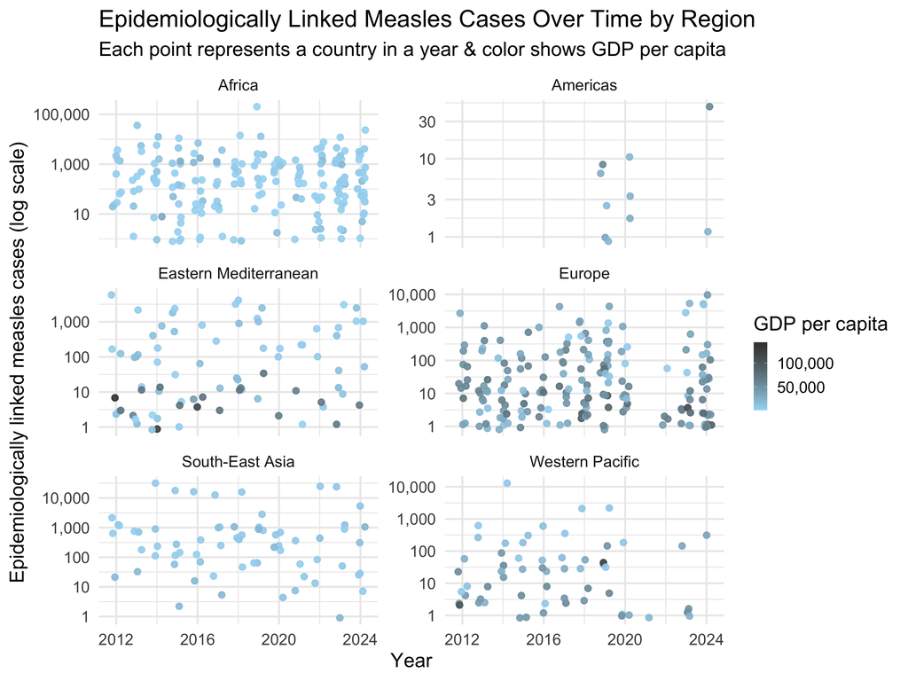

Figure 3. Epidemiologically Linked Measles Cases and GDP per Capita by Region.

```r
# faceted plot by region
ggplot(cases_gdp_year,
       aes(x = year,
           y = measles_epi_linked,
           color = gdp_per_capita)) +
  geom_jitter(alpha = 0.9, size = 3, width = 0.25, height = 0.1) +
  scale_y_log10(labels = scales::comma) +
  scale_x_continuous(breaks = c(2012, 2016, 2020, 2024)) +
  scale_color_gradient(
    low = "#A6DAF5",
    high = "#3E3F3A",
    labels = scales::comma
  ) +
  facet_wrap(~ region, ncol = 2, scales = "free_y") +
  labs(
    title = "Epidemiologically Linked Measles Cases Over Time by Region",
    subtitle = "Each point represents a country in a year & color shows GDP per capita",
    x = "Year",
    y = "Epidemiologically linked measles cases (log scale)",
    color = "GDP per capita"
  ) +
  theme_minimal(base_size = 25)
```

As shown in Figure 3, there are regional differences in epidemiologically linked measles cases for changes GDP per capita. Africa and South-East Asia show a range of case counts for countries, but are mostly lower GDP countries. The Americas have very few epidemiologically linked cases across years, suggesting that cases in this region are usually linked less through geographic transmission patterns. Europe has varying case counts across years and don’t appear to be associated with GDP. However, the Eastern Mediterranean and Western Pacific regions show a clear pattern that higher GDP countries tend to have lower numbers of epidemiologically linked measles cases, and lower GDP countries tend to have higher case counts.

```r
# function to get proportion of epidemiologically-linked cases for each year in one region
epi_proportions <- function(region_code) {
  cases_month |>
    filter(.data$region == region_code) |>
    group_by(year) |>
    # get total counts for each year
    summarise(
      # measles total epidemiologically-linked and lab confirmed
      measles_epi_linked = sum(measles_epi_linked, na.rm = TRUE),
      measles_lab_confirmed = sum(measles_lab_confirmed, na.rm = TRUE),
      .groups = "drop"
    ) |>
    # modify columns by calculating proportions
    mutate(
      prop_epi_measles = measles_epi_linked /
        (measles_epi_linked + measles_lab_confirmed)
    ) |>
    select(year, prop_epi_measles)
}

cases_month |>
  distinct(region) |>
  # rename regions to full names
  mutate(
    region_name = recode(region,
      "AFR" = "Africa",
      "AMR" = "Americas",
      "EMR" = "Eastern Mediterranean",
      "EUR" = "Europe",
      "SEAR" = "South-East Asia",
      "WPR" = "Western Pacific"
    )
  ) |>
  # apply function to get proportions for each region
  mutate(epi_props = map(region, epi_proportions)) |>
  # get columns from returned map lists
  unnest(epi_props) |>
  # keep only region name, year, and proportion
  select(region_name, year, prop_epi_measles) |>
  # group by region so the table is divided by region
  group_by(region_name) |>
  # make a gt table
  gt() |>
  # format the proportion columns to be percents
  fmt_percent(columns = matches("prop"), decimals = 1) |>
  # bold region group labels
  tab_style(
    style = cell_text(weight = "bold"),
    locations = cells_row_groups()
  ) |>
  # rename and bold column names
  cols_label(
    region_name = md("**Region**"),
    year = md("**Year**"),
    prop_epi_measles = md("**Epidemiologically-linked measles cases**")
  ) |>
  # add a table title
  tab_header(
    title = md("Proportion of Confirmed Cases that are Epidemiologically-linked")
  ) |>
  # add a table caption
  tab_caption(
    caption = md("Changes in each region's confirmed measles cases makeup over time.")
  ) |>
  opt_interactive()
```

Proportion of Confirmed Cases that are Epidemiologically-linked

[output not shown]

[output cut: 72 more lines]

In Table 3, the proportion of confirmed measles cases that are epidemiologically linked continue to show variation across regions and over time. Africa and South-East Asia have higher proportions, meaning a larger number of cases are linked through geographic transmission. Europe and the Eastern Mediterranean show moderate and slightly varying proportions over time. The Americas and Western Pacific regions show very low proportions over time, and that less cases are epidemiologically linked.

```r
# calculation of global GDP level groups: low, medium, and high
cases_gdp_year_global <- cases_gdp_year |>
  mutate(
    gdp_group = ntile(gdp_per_capita, 3),
    gdp_group = recode(as.character(gdp_group),
      "1" = "Low GDP",
      "2" = "Medium GDP",
      "3" = "High GDP"
    ),
    gdp_group = factor(gdp_group,
      levels = c("Low GDP", "Medium GDP", "High GDP")
    )
  )

# function to get total epidemiologically-linked cases by GDP group for one region
gdp_epi_groups <- function(region_name) {
  cases_gdp_year_global |>
    filter(.data$region == region_name) |>
    group_by(gdp_group) |>
    summarise(
      epi_linked_cases = sum(measles_epi_linked, na.rm = TRUE),
      .groups = "drop"
    )
}

cases_gdp_year |>
  distinct(region) |>
  # apply function to get GDP groups for each region
  mutate(gdp_epi = map(region, gdp_epi_groups)) |>
  # get columns from returned map lists
  unnest(gdp_epi) |>
  # keep GDP levels with 0 cases
  complete(region, gdp_group, fill = list(epi_linked_cases = 0)) |>
  # group by region so the table is divided by region
  group_by(region) |>
  # make a gt table
  gt() |>
  # format the epidemiologically-linked case counts
  fmt_number(columns = epi_linked_cases, decimals = 0) |>
  # bold region group labels
  tab_style(
    style = cell_text(weight = "bold"),
    locations = cells_row_groups()
  ) |>
  # rename and bold column names
  cols_label(
    region = md("**Region**"),
    gdp_group = md("**GDP Level**"),
    epi_linked_cases = md("**Epidemiologically-linked measles cases**")
  ) |>
  # add a table title
  tab_header(
    title = md("Epidemiologically-linked Measles Cases by Regional GDP Level")
  ) |>
  # add a table caption
  tab_caption(
    caption = md("Total epidemiologically-linked measles cases grouped by global GDP per capita
                 low, medium, and high within each region. Based on yearly country observations
                 from 2012–2024.")
  )
```

Table 4. Epidemiologically-linked counts by GDP levels of regions.

Epidemiologically-linked Measles Cases by Regional GDP Level

| **GDP Level** | **Epidemiologically-linked measles cases** |
| --- | --- |
| Africa |  |
| Low GDP | 362,135 |
| Medium GDP | 119,434 |
| High GDP | 7 |
| Americas |  |
| Low GDP | 0 |
| Medium GDP | 27 |
| High GDP | 61 |
| Eastern Mediterranean |  |
| Low GDP | 28,299 |
| Medium GDP | 11,438 |
| High GDP | 139 |
| Europe |  |
| Low GDP | 2,645 |
| Medium GDP | 23,970 |
| High GDP | 32,905 |
| South-East Asia |  |
| Low GDP | 34,879 |
| Medium GDP | 127,121 |
| High GDP | 0 |
| Western Pacific |  |
| Low GDP | 0 |
| Medium GDP | 17,357 |
| High GDP | 1,037 |

Total epidemiologically linked measles cases differ across GDP levels within regions. In Africa and the Eastern Mediterranean, most cases occur in low GDP countries which supports the trends in the visualizations of regions (Figure 3). South-East Asia and Western Pacific show a concentration of cases in medium GDP countries, with Western Pacific having few overall cases. The Americas have relatively very few cases overall. Europe differs from other regions by most cases occurring in medium and high GDP countries, showing the higher GDP trend across countries within the region (Table 4).

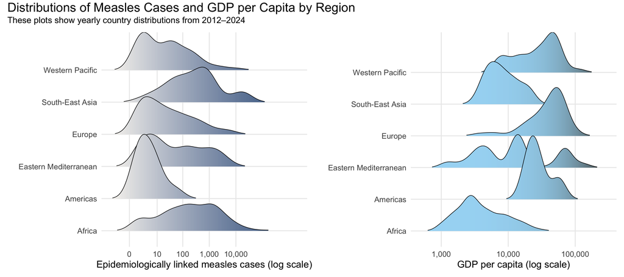

Figure 4. Epidemiologically Linked Measles Cases and GDP per Capita by Region

```r
epi_region_plot <- cases_gdp_year |>
  ggplot(aes(x = log1p(measles_epi_linked),
             y = region,
             fill = ..x..)) +
  geom_density_ridges_gradient(scale = 2, rel_min_height = 0.01) +
  scale_x_continuous(
    breaks = log1p(c(0, 10, 100, 1000, 10000)),
    labels = scales::comma(c(0, 10, 100, 1000, 10000))
  ) +
  scale_fill_gradient(
    low = "#F8F5F0",
    high = "#325D88"
  ) +
  scale_y_discrete(expand = c(0.0001, 0.5)) +
  labs(
    #title = "Distribution of Epidemiologically Linked Measles Cases by Region",
    #subtitle = "Country-year observations from 2012–2024",
    x = "Epidemiologically linked measles cases (log scale)",
    y = "",
    fill = "Cases"
  ) +
  theme_minimal(base_size = 20) +
  theme(
    panel.grid.minor.x = element_blank(),
    legend.position = "none"
  )

gdp_region <- cases_gdp_year |>
  ggplot(aes(x = gdp_per_capita,
             y = region,
             fill = ..x..)) +
  geom_density_ridges_gradient(scale = 2, rel_min_height = 0.01) +
  scale_x_log10(labels = scales::label_comma()) +
  scale_fill_gradient(
    low = "#A6DAF5",
    high = "#3E3F3A"
  ) +
  scale_y_discrete(expand = c(0.0001, 0.5)) +
  labs(
    #title = "Distribution of GDP per Capita by Region",
    #subtitle = "Country-year observations from 2012–2024",
    x = "GDP per capita (log scale)",
    y = "",
    fill = "GDP per capita"
  ) +
  theme_minimal(base_size = 20) +
  theme(
    panel.grid.minor.x = element_blank(),
    legend.position = "none"
  )

epi_region_plot + gdp_region +
  plot_layout(ncol = 2) +
  plot_annotation(
    title = "Distributions of Measles Cases and GDP per Capita by Region",
    subtitle = "These plots show yearly country distributions from 2012–2024",
    theme = theme(
      plot.title = element_text(size = 26),
      plot.subtitle = element_text(size = 18)
    )
  )
```

To understand the findings of differences in epidemiologically linked measles cases and GDP per capita across regions, the distribution of each is visualized in Figure 4. Epidemiologically linked cases show the Americas have the lowest case levels, Europe, Eastern Mediterranean, and the Western Pacific have slightly higher cases, and Africa and South-East Asia have the highest concentrations of cases. The distribution of GDP per capita shows that Africa has the lowest GDP levels, then Eastern Mediterranean and South-East Asia, followed with the Americas and Western Pacific that have higher GDP levels, and Europe has the highest overall. This explains the patterns found in Figure 3, as limited GDP differences within Europe, Africa, and South-East Asia makes it challenging to identify a clear relationship between GDP and epidemiologically linked measles cases.

#### **To further investigate this relationship, we fit a mixed-effects log-linear regression model with country included as a random effect.**

As a reminder, we are looking to answer if countries with lower GDP per capita are associated with higher numbers of epidemiologically linked measles cases. In addition, we want to see if this relationship varies by region of the world.

This model evaluates the relationship between GDP per capita and epidemiologically linked measles cases. GDP per capita is used as a measure of a country’s economic development, and epidemiologically linked cases show patterns of disease transmission based on geography. The model uses country-year observations from 2012 to 2024. The variables are both log-transformed to account for skewness across countries, since changes at lower income levels might have a larger impact than at higher income levels. This is consistent with used approaches in recent global health research.

Region is included as a categorical variable to account for structural differences in disease transmission and reporting across geographic areas, and country is included as a random effect to account for repeated yearly observations within countries. Africa (AFRO) is used as the reference region, so all regional estimates reflect differences relative to Africa. We fit a simple log-log linear regression model to explore the relationship between GDP per capita and epidemiologically linked measles cases without accounting for region or repeated country observations. Next, we address the limitations of this exploratory model with a mixed-effects model. A likelihood ratio test was used to compare a model with a GDP-by-region interaction to a simpler model without the interaction to determine whether the relationship between GDP per capita and epidemiologically linked measles cases differed across regions. The model includes six fixed-effect hypothesis tests, thus a Bonferroni correction was applied by adjusting the significance threshold to α = 0.0083 (0.05 / 6) to reduce the risk of type 1 error inflation from multiple comparisons.

```r
epi_gdp_model_data <- cases_gdp |>
  distinct(country, year, region_year, gdp_per_capita, measles_epi_linked_year) |>
  rename(region = region_year) |>
  filter(
    year != 2025,
    gdp_per_capita > 0
  ) |>
  drop_na(gdp_per_capita, measles_epi_linked_year, region) |>
  mutate(
    region = factor(region),
    log_gdp = log10(gdp_per_capita),
    log_epi_linked = log1p(measles_epi_linked_year)
  )

# fit simple model (exploratory, no region or random effect)
epi_gdp_simple_model <- lm(
  log_epi_linked ~ log_gdp,
  data = epi_gdp_model_data
)

# fit mixed model with GDP, region, and GDP-by-region interaction
epi_gdp_model <- lmer(
  log_epi_linked ~ log_gdp * region + (1 | country),
  data = epi_gdp_model_data
)

# fit simpler model without interaction
epi_gdp_model_no_interaction <- lmer(
  log_epi_linked ~ log_gdp + region + (1 | country),
  data = epi_gdp_model_data
)

# compare simpler model to interaction model
model_comparison <- anova(
  epi_gdp_model_no_interaction,
  epi_gdp_model
)

# make simple model coefficient table
simple_table <- as.data.frame(summary(epi_gdp_simple_model)$coefficients) |>
  rownames_to_column(var = "term") |>
  rename(
    estimate = Estimate,
    std_error = `Std. Error`,
    t_statistic = `t value`,
    p_value = `Pr(>|t|)`
  ) |>
  mutate(
    result_type = "Simple model",
    chisq = NA_real_,
    df = NA_real_,
    conclusion = case_when(
      p_value < 0.05 ~ "Significant",
      TRUE ~ "Not significant"
    )
  ) |>
  select(
    result_type,
    term,
    estimate,
    std_error,
    df,
    t_statistic,
    chisq,
    p_value,
    conclusion
  )

# make coefficient table from mixed model
coef_table <- as.data.frame(summary(epi_gdp_model_no_interaction)$coefficients) |>
  rownames_to_column(var = "term") |>
  rename(
    estimate = Estimate,
    std_error = `Std. Error`,
    df = df,
    t_statistic = `t value`,
    p_value = `Pr(>|t|)`
  ) |>
  mutate(
    result_type = "Mixed model",
    chisq = NA_real_,
    conclusion = case_when(
      p_value < (0.05 / 6) ~ "Significant",  # Bonferroni correction for 6 tests
      TRUE ~ "Not significant"
    )
  ) |>
  select(
    result_type,
    term,
    estimate,
    std_error,
    df,
    t_statistic,
    chisq,
    p_value,
    conclusion
  )

# make model comparison row
comparison_table <- tibble(
  result_type = "Interaction Model comparison",
  term = "GDP by region interaction",
  estimate = NA_real_,
  std_error = NA_real_,
  df = model_comparison$Df[2],
  t_statistic = NA_real_,
  chisq = model_comparison$Chisq[2],
  p_value = model_comparison$`Pr(>Chisq)`[2],
  conclusion = case_when(
    p_value < 0.05 ~ "Significant",
    TRUE ~ "Not significant"
  )
)

# combine into one gt table
bind_rows(simple_table, coef_table, comparison_table) |>
  gt(groupname_col = "result_type") |>
  fmt_number(
    columns = c(estimate, std_error, df, t_statistic, chisq, p_value),
    decimals = 3
  ) |>
  sub_missing(
    columns = c(estimate, std_error, df, t_statistic, chisq, p_value),
    missing_text = ""
  ) |>
  sub_small_vals(
    columns = p_value,
    threshold = 0.001
  ) |>
  cols_align(align = "center") |>
  cols_label(
    term = "Model Term",
    estimate = "Estimate",
    std_error = "Standard Error",
    df = "df",
    t_statistic = "t Statistic",
    chisq = "Chi-square",
    p_value = "p-value",
    conclusion = "Conclusion"
  ) |>
  tab_header(
    title = "Model Results: GDP, Region, and Epidemiologically Linked Measles Cases",
    subtitle = "Mixed-effects model with country as a random effect"
  ) |>
  tab_caption(
    caption = "Table includes the simple exploratory model, the mixed-effects model, and the likelihood ratio test comparing it to the GDP by region interaction model."
  ) |>
  tab_style(
    style = list(
      cell_fill(color = "#DCEAF4"),
      cell_text(weight = "bold", size = px(15))
    ),
    locations = cells_row_groups()
  ) |>
  tab_style(
    style = cell_text(weight = "bold"),
    locations = cells_column_labels()
  )
```

Table 5. Mixed model results analyzing GDP, region, and epidemiologically linked measles cases.

Model Results: GDP, Region, and Epidemiologically Linked Measles Cases

Mixed-effects model with country as a random effect

| Model Term | Estimate | Standard Error | df | t Statistic | Chi-square | p-value | Conclusion |
| --- | --- | --- | --- | --- | --- | --- | --- |
| Simple model |  |  |  |  |  |  |  |
| (Intercept) | 4.410 | 0.441 |  | 9.996 |  | <0.001 | Significant |
| log_gdp | −0.756 | 0.106 |  | −7.117 |  | <0.001 | Significant |
| Mixed model |  |  |  |  |  |  |  |
| (Intercept) | 2.171 | 1.153 | 222.135 | 1.883 |  | 0.061 | Not significant |
| log_gdp | −0.078 | 0.311 | 226.599 | −0.252 |  | 0.801 | Not significant |
| regionAMRO | −1.780 | 0.423 | 180.520 | −4.211 |  | <0.001 | Significant |
| regionEMRO | −0.506 | 0.474 | 167.277 | −1.069 |  | 0.287 | Not significant |
| regionEURO | −0.805 | 0.437 | 184.329 | −1.844 |  | 0.067 | Not significant |
| regionSEARO | 1.549 | 0.588 | 161.778 | 2.633 |  | 0.009 | Not significant |
| regionWPRO | −1.064 | 0.454 | 171.762 | −2.343 |  | 0.020 | Not significant |
| Interaction Model comparison |  |  |  |  |  |  |  |
| GDP by region interaction |  |  | 5.000 |  | 9.098 | 0.105 | Not significant |

The simple exploratory model shows that GDP per capita is negatively and significantly associated with epidemiologically linked measles cases (p < 0.001) alone, meaning higher GDP per capita is associated with lower cases. However, this model does not account for repeated country observations or regional differences.

The model results show that there isn’t enough statistically significant evidence that the relationship between GDP per capita and epidemiologically linked measles cases differs across regions. The likelihood ratio test comparing the interaction model to the simpler model was not statistically significant (p-value = 0.105), so the simpler mixed-effects model without the interaction was used for interpretation.

Also, the results show regional differences in epidemiologically linked measles cases after accounting for GDP per capita and repeated country observations over years. Using Africa as the reference region, and applying a Bonferroni correction (α = 0.0083) to account for multiple comparisons, only the Americas (AMRO) are significantly associated with low log-transformed epidemiologically linked measles cases. Western Pacific (WPRO) and South-East Asia (SEARO) did not meet the adjusted significance threshold and therefore not significantly associated with log-transformed cases. Eastern Mediterranean (EMRO) and Europe (EURO) also don’t show statistically significant differences from Africa.

Interestingly, GDP per capita was significant in the simple model but not significant after accounting for regional differences and repeated country observations. This suggests that the initial association between GDP per capita and epidemiologically linked measles cases was partly explained by regional and country variation.

Overall, the results indicate that epidemiologically linked measles cases vary across regions, but there isn’t enough statistically significant evidence that the relationship between GDP per capita and epidemiologically linked measles cases changes by region. Finally, there isn’t enough statistically significant evidence of an overall association between GDP per capita and epidemiologically linked measles cases after accounting for regional differences and repeated country observations.